# Elastic Net Regression for Quantifying Coffee Adulteration: Spectral Preprocessing Using SNV, Savitzky-Golay, and First Derivative

Author

Derick Malavi

## Introduction

Coffee adulteration, such as blending premium Arabica with lower-cost Robusta, undermines quality and authenticity, posing significant challenges for consumers, producers, and regulators. High-dimensional spectroscopic data provides valuable insights for detecting such fraud, but the large number of variables necessitates effective techniques to manage dimensionality and isolate the most relevant wavelengths.

This study employs Elastic Net regression, a robust technique that combines the strengths of elastic_net (L1 regularization) and Ridge (L2 regularization). Elastic Net balances feature selection and coefficient shrinkage, effectively addressing multicollinearity while retaining critical spectral features. This approach enables efficient modeling with high-dimensional data by reducing redundancy and improving prediction accuracy.

```r
# Load libraries
warning = FALSE
  suppressWarnings(suppressMessages({
  library(caret)
  library(GA)
  library(glmnet)
  library(viridis)
  library(Boruta)
  library(ggplot2)
  library(dplyr)
  library(readxl)
  library(readr)
  library(janitor)
  library(class)
  library(MLmetrics)
  library(MLeval)
  library(themis)
  library(ROSE)
  library(parallel)
  library(doParallel)
  library(foreach)
  library(pheatmap)
  library(mdatools)
  library(nnet)
  library(DMwR)
  library(e1071)
  library(knitr)
  library(pROC)
  library(gridExtra)
  library(FactoMineR)
  library(doSNOW)
  library(MASS)
  library(factoextra)
  library(kernlab)}))
```

## Prepare Data

```r
# Load data: snv_sg_1d spectra

hsi_snv_sg_1d <- read.csv("coffee_ground_snv_sg_1d.csv")

# Ensure we have the same number of dimensions and the range of our columns/covariates
dim(hsi_snv_sg_1d)
```

```
[1] 1469  229
```

```r
# Check a few column names
col_check <- colnames(hsi_snv_sg_1d[,c(1:6)])
col_check
```

```
[1] "sample_id"     "binary_class"  "three_class"   "adult_percent"
[5] "cal_val"       "X935.609985"
```

```r
# our response variable (adulteration percentage) is column 4
# The spectral values start from column # 6 -------> 229

# Convert the adulteration percentage to numeric for compatibility with ML
hsi_snv_sg_1d$adult_percent <- as.numeric(hsi_snv_sg_1d$adult_percent)
```

## Get the X and y variables

```r
X <- hsi_snv_sg_1d[,c(6:229)]
y <- hsi_snv_sg_1d[,4]

class(y) #Ensure y (target variable) is a numeric for regression
```

```
[1] "numeric"
```

## Visualize X

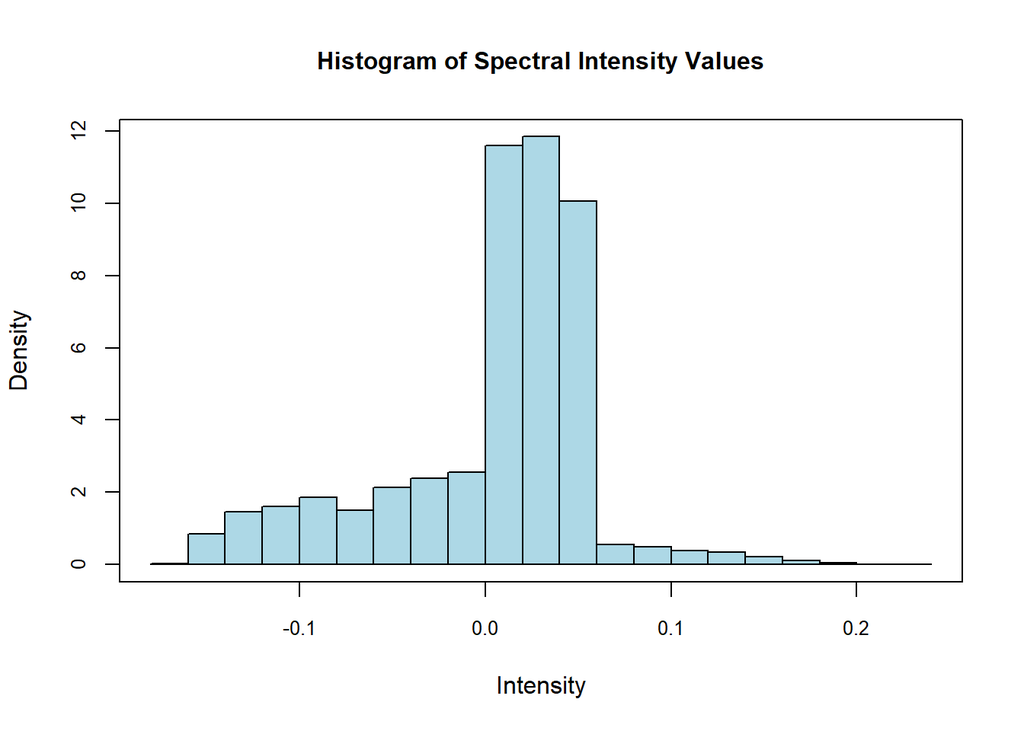

```r
hist(as.matrix(X), col = 'lightblue', cex.main = 1.0, cex.axis = 0.8,cex.lab = 1.0,freq = FALSE,
     main = 'Histogram of Spectral Intensity Values', xlab = 'Intensity'); box()
```

## Split the Data (Train_Test Split)

- We want to select features based on training data only to avoid any data leakage that could inflate model performance and make the model less generalizable to unseen data.

```r
# Subset samples for cross-validation and external validation (70/30)
# Record 1 under cal_val variable is for calibration while 2 will be for testing the model

sample<-hsi_snv_sg_1d$cal_val == 1

# Split to train and test sets
X_train <- X[sample,]
X_test <- X[!sample,]
y_train <-y[sample]
y_test <- y[!sample]

# Check length of the subsets for training and validation
dim(X_train)
```

```
[1] 1055  224
```

```r
dim(X_test)
```

```
[1] 414 224
```

```r
length(y_train)
```

```
[1] 1055
```

```r
length(y_test)
```

```
[1] 414
```

```r
# Merge the test and train data
train_data <- data.frame(y_train, X_train)
test_data <- data.frame(y_test, X_test)
```

## Train Models

```r
# Set random seed for reproducibility
set.seed (123)

# Set up the training control(10 folds 10 times cross_validation)
control <- trainControl(method = "repeatedcv", number = 10, repeats = 10,
                        savePredictions = "final",
                        summaryFunction = defaultSummary,
                        selectionFunction = 'best', allowParallel = TRUE)

# We used oneSE for classification. For regression, we will use 'best': a model that minimizes RMSECV
```

```r
#Set the metric as accuracy
metric<-"RMSE"
```

```r
# Hyperparameter set Elastic Net Regression
# alpha: Set for L1(elastic_net) and L2(Ridge) Regression
# lambda: Regularization strength (penalty parameter). A sequence of values is tested to identify the best lambda.

grid <- expand.grid( alpha = seq(0, 1, length = 10),  # Explore between Ridge (alpha = 0) and elastic_net (alpha = 1)
    lambda = seq(0.001, 0.1, length = 10))
```

# Train Elastic Net

```r
set.seed(123)
#Register cluster for caret to train the models in parallel
cl<-makeCluster(6,type = "SOCK")
suppressWarnings(suppressMessages(
  registerDoSNOW(cl)))

# Start_time
start_time<-Sys.time()

#Train the model using cross-validation (10 folds, 10 times)
fit_elastic_net_snv_sg_1d<-train(y = train_data[,1],
                         x = train_data[,-1],
                         method = 'glmnet', tuneGrid = grid,
                         trControl = control, preProcess = c("center","scale"),
                         metric = metric)
#End_time
end_time<-Sys.time()

model_training_time<-end_time-start_time

stopCluster(cl) # Stop the parallel run cluster

print(model_training_time)
```

```
Time difference of 3.292992 mins
```

```r
# Display regression results
print(fit_elastic_net_snv_sg_1d)
```

```
glmnet

1055 samples
 224 predictor

Pre-processing: centered (224), scaled (224)
Resampling: Cross-Validated (10 fold, repeated 10 times)
Summary of sample sizes: 949, 949, 949, 948, 949, 950, ...
Resampling results across tuning parameters:

  alpha      lambda  RMSE      Rsquared   MAE
  0.0000000  0.001   8.846034  0.9072374  7.056210
  0.0000000  0.012   8.846034  0.9072374  7.056210
  0.0000000  0.023   8.846034  0.9072374  7.056210
  0.0000000  0.034   8.846034  0.9072374  7.056210
  0.0000000  0.045   8.846034  0.9072374  7.056210
  0.0000000  0.056   8.846034  0.9072374  7.056210
  0.0000000  0.067   8.846034  0.9072374  7.056210
  0.0000000  0.078   8.846034  0.9072374  7.056210
  0.0000000  0.089   8.846034  0.9072374  7.056210
  0.0000000  0.100   8.846034  0.9072374  7.056210
  0.1111111  0.001   6.536137  0.9491780  5.137151
  0.1111111  0.012   6.536137  0.9491780  5.137151
  0.1111111  0.023   6.560563  0.9487910  5.158181
  0.1111111  0.034   6.658417  0.9472510  5.247168
  0.1111111  0.045   6.742326  0.9459236  5.321936
  0.1111111  0.056   6.816033  0.9447460  5.385059
  0.1111111  0.067   6.877617  0.9437538  5.436738
  0.1111111  0.078   6.930550  0.9428999  5.480711
  0.1111111  0.089   6.979820  0.9420958  5.520183
  0.1111111  0.100   7.026109  0.9413355  5.557509
  0.2222222  0.001   6.509375  0.9495557  5.120376
  0.2222222  0.012   6.521969  0.9493635  5.131338
  0.2222222  0.023   6.621867  0.9478086  5.220507
  0.2222222  0.034   6.742033  0.9459189  5.329855
  0.2222222  0.045   6.842325  0.9443170  5.416212
  0.2222222  0.056   6.929993  0.9428945  5.488970
  0.2222222  0.067   7.013584  0.9415236  5.556501
  0.2222222  0.078   7.097279  0.9401386  5.623813
  0.2222222  0.089   7.171979  0.9388858  5.685679
```

[output cut: 59 more lines]

```
  0.8888889  0.089   8.020375  0.9236522  6.364606
  0.8888889  0.100   8.140419  0.9213779  6.463041
  1.0000000  0.001   6.450977  0.9504310  5.081711
  1.0000000  0.012   6.659225  0.9472243  5.277742
  1.0000000  0.023   7.014558  0.9414683  5.563761
  1.0000000  0.034   7.268433  0.9371918  5.758194
  1.0000000  0.045   7.455278  0.9339603  5.903376
  1.0000000  0.056   7.642733  0.9306342  6.055866
  1.0000000  0.067   7.801053  0.9277477  6.183994
  1.0000000  0.078   7.977708  0.9244408  6.327444
  1.0000000  0.089   8.105842  0.9220322  6.429732
  1.0000000  0.100   8.222702  0.9197922  6.525623

RMSE was used to select the optimal model using the smallest value.
The final values used for the model were alpha = 0.8888889 and lambda = 0.001.
```

#### Best hyperparameters

```r
# Best lambda value
best_lambda <- fit_elastic_net_snv_sg_1d$bestTune$lambda

cat("Best Lambda:", best_lambda, "\n")
```

```
Best Lambda: 0.001
```

#### Extract Selected Features

```r
# Extract coefficients from the best model
coefficients <- coef(fit_elastic_net_snv_sg_1d$finalModel, s = best_lambda)

# Convert to a readable format
elastic_net_coefficients <- as.data.frame(as.matrix(coefficients))
colnames(elastic_net_coefficients) <- "Coefficient"
elastic_net_coefficients$Variable <- rownames(elastic_net_coefficients)

# Filter non-zero coefficients (selected features)
selected_features <- elastic_net_coefficients[elastic_net_coefficients$Coefficient != 0, ]
print(selected_features)
```

```
               Coefficient     Variable
(Intercept)   3.016019e+01  (Intercept)
X935.609985   1.445024e+00  X935.609985
X966.72998   -1.137839e+00   X966.72998
X970.190002  -1.013769e+00  X970.190002
X977.109985   7.651442e-01  X977.109985
X980.580017   1.752882e+00  X980.580017
X997.900024   1.777238e+01  X997.900024
X1018.710022 -1.337137e-01 X1018.710022
X1022.179993 -1.259867e+00 X1022.179993
X1029.119995 -4.558734e+00 X1029.119995
X1032.589966 -6.197608e+00 X1032.589966
X1043         2.792471e-05        X1043
X1056.900024  1.364502e+00 X1056.900024
X1063.849976 -8.352178e-04 X1063.849976
X1067.329956 -2.369710e+00 X1067.329956
X1091.680054 -1.398000e-04 X1091.680054
X1095.170044 -7.776408e+00 X1095.170044
X1109.099976 -1.361766e+01 X1109.099976
X1112.579956 -1.068940e+00 X1112.579956
X1126.52002   6.223566e-04  X1126.52002
X1130.01001   1.527439e-03  X1130.01001
X1157.930054 -2.366581e-03 X1157.930054
X1161.420044 -2.870911e+00 X1161.420044
X1178.890015  9.257555e-06 X1178.890015
X1182.380005  3.629901e-02 X1182.380005
X1185.880005  5.754211e-02 X1185.880005
X1189.369995  1.048789e+00 X1189.369995
X1192.869995  4.737726e+00 X1192.869995
X1196.369995  1.857957e+00 X1196.369995
X1199.869995  2.866396e+01 X1199.869995
X1203.369995  4.503276e-01 X1203.369995
X1213.869995  1.161650e+01 X1213.869995
X1220.869995  3.780900e+00 X1220.869995
X1224.369995  2.856675e-04 X1224.369995
X1231.380005  1.511814e-03 X1231.380005
X1234.880005  2.842890e+01 X1234.880005
X1238.390015  1.656940e+00 X1238.390015
X1252.410034 -2.753895e-04 X1252.410034
X1255.920044 -1.036418e+00 X1255.920044
```

[output cut: 57 more lines]

```
X1616.609985  5.596195e-04 X1616.609985
X1627.310059 -2.949304e-02 X1627.310059
X1630.869995 -1.670445e+00 X1630.869995
X1641.579956  6.748483e-02 X1641.579956
X1645.150024  6.997979e+00 X1645.150024
X1652.290039 -1.166833e+01 X1652.290039
X1655.859985 -1.285830e+01 X1655.859985
X1659.430054 -2.243621e-04 X1659.430054
X1666.569946  5.249457e-04 X1666.569946
X1670.140015  9.919941e-02 X1670.140015
X1673.719971  1.318253e+01 X1673.719971
X1677.290039  6.635995e+00 X1677.290039
X1680.869995  3.695691e+00 X1680.869995
X1684.439941  1.975002e+01 X1684.439941
X1688.02002   1.702883e+00  X1688.02002
```

```r
# Sort the selected features by actual values in descending order
selected_features_sorted_actual <- selected_features[order(selected_features$Coefficient, decreasing = TRUE), ]

# Print the sorted features
print(selected_features_sorted_actual)
```

```
               Coefficient     Variable
(Intercept)   3.016019e+01  (Intercept)
X1199.869995  2.866396e+01 X1199.869995
X1234.880005  2.842890e+01 X1234.880005
X1456.76001   2.546923e+01  X1456.76001
X1684.439941  1.975002e+01 X1684.439941
X1559.640015  1.795908e+01 X1559.640015
X1605.920044  1.783250e+01 X1605.920044
X997.900024   1.777238e+01  X997.900024
X1371.969971  1.766760e+01 X1371.969971
X1613.040039  1.707043e+01 X1613.040039
X1368.439941  1.444810e+01 X1368.439941
X1673.719971  1.318253e+01 X1673.719971
X1513.459961  1.244339e+01 X1513.459961
X1361.390015  1.195656e+01 X1361.390015
X1407.26001   1.194227e+01  X1407.26001
X1213.869995  1.161650e+01 X1213.869995
X1298.050049  1.133002e+01 X1298.050049
X1509.910034  1.121118e+01 X1509.910034
X1301.560059  1.000440e+01 X1301.560059
X1357.869995  9.574994e+00 X1357.869995
X1645.150024  6.997979e+00 X1645.150024
X1677.290039  6.635995e+00 X1677.290039
X1460.300049  6.093280e+00 X1460.300049
X1192.869995  4.737726e+00 X1192.869995
X1220.869995  3.780900e+00 X1220.869995
X1680.869995  3.695691e+00 X1680.869995
X1566.75      3.413585e+00     X1566.75
X1305.079956  2.354068e+00 X1305.079956
X1485.089966  2.308892e+00 X1485.089966
X1563.199951  1.912929e+00 X1563.199951
X1453.219971  1.879361e+00 X1453.219971
X1196.369995  1.857957e+00 X1196.369995
X980.580017   1.752882e+00  X980.580017
X1688.02002   1.702883e+00  X1688.02002
X1238.390015  1.656940e+00 X1238.390015
X1280.47998   1.572517e+00  X1280.47998
X1481.550049  1.562554e+00 X1481.550049
X1291.02002   1.453947e+00  X1291.02002
X935.609985   1.445024e+00  X935.609985
```

[output cut: 57 more lines]

```
X1032.589966 -6.197608e+00 X1032.589966
X1517.01001  -6.525946e+00  X1517.01001
X1336.73999  -7.258923e+00  X1336.73999
X1095.170044 -7.776408e+00 X1095.170044
X1652.290039 -1.166833e+01 X1652.290039
X1470.920044 -1.240571e+01 X1470.920044
X1655.859985 -1.285830e+01 X1655.859985
X1109.099976 -1.361766e+01 X1109.099976
X1333.219971 -1.416336e+01 X1333.219971
X1439.069946 -1.703286e+01 X1439.069946
X1262.930054 -1.705030e+01 X1262.930054
X1442.599976 -1.807160e+01 X1442.599976
X1340.26001  -1.862123e+01  X1340.26001
X1259.420044 -2.167158e+01 X1259.420044
X1584.550049 -2.278682e+01 X1584.550049
```

```r
print(paste('The number of feautures selected by elastic_net are', nrow(selected_features_sorted_actual)))
```

```
[1] "The number of feautures selected by elastic_net are 111"
```

## Save the models for future use

```r
saveRDS(fit_elastic_net_snv_sg_1d, "fit_elastic_net_snv_sg_1d.rds")
```

#### Coefficients vs. Lambda Path

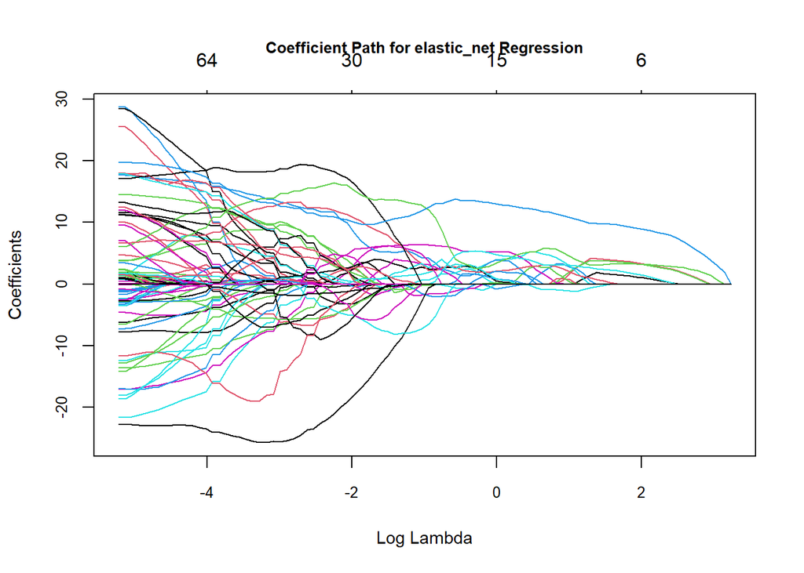

```r
# Extract the final glmnet model
fit_glmnet <- fit_elastic_net_snv_sg_1d$finalModel

# Plot coefficients vs. lambda
par(cex.main = 0.8)
plot(
  fit_glmnet,
  xvar = "lambda",
  label = FALSE,
  cex.axis = 0.8,
  cex.lab = 0.9,
  cex.main = 0.3)
title(main = "Coefficient Path for elastic_net Regression")
```

```r
#As lambda increases, coefficients shrink toward zero, highlighting the feature selection process
```

## Display CV Results in Tables

```r
kable(fit_elastic_net_snv_sg_1d$results)
```

| alpha | lambda | RMSE | Rsquared | MAE | RMSESD | RsquaredSD | MAESD |
| --- | --- | --- | --- | --- | --- | --- | --- |
| 0.0000000 | 0.001 | 8.846034 | 0.9072374 | 7.056210 | 0.6403000 | 0.0120829 | 0.4619500 |
| 0.0000000 | 0.012 | 8.846034 | 0.9072374 | 7.056210 | 0.6403000 | 0.0120829 | 0.4619500 |
| 0.0000000 | 0.023 | 8.846034 | 0.9072374 | 7.056210 | 0.6403000 | 0.0120829 | 0.4619500 |
| 0.0000000 | 0.034 | 8.846034 | 0.9072374 | 7.056210 | 0.6403000 | 0.0120829 | 0.4619500 |
| 0.0000000 | 0.045 | 8.846034 | 0.9072374 | 7.056210 | 0.6403000 | 0.0120829 | 0.4619500 |
| 0.0000000 | 0.056 | 8.846034 | 0.9072374 | 7.056210 | 0.6403000 | 0.0120829 | 0.4619500 |
| 0.0000000 | 0.067 | 8.846034 | 0.9072374 | 7.056210 | 0.6403000 | 0.0120829 | 0.4619500 |
| 0.0000000 | 0.078 | 8.846034 | 0.9072374 | 7.056210 | 0.6403000 | 0.0120829 | 0.4619500 |
| 0.0000000 | 0.089 | 8.846034 | 0.9072374 | 7.056210 | 0.6403000 | 0.0120829 | 0.4619500 |
| 0.0000000 | 0.100 | 8.846034 | 0.9072374 | 7.056210 | 0.6403000 | 0.0120829 | 0.4619500 |
| 0.1111111 | 0.001 | 6.536137 | 0.9491780 | 5.137151 | 0.4608428 | 0.0065799 | 0.3687925 |
| 0.1111111 | 0.012 | 6.536137 | 0.9491780 | 5.137151 | 0.4608428 | 0.0065799 | 0.3687925 |
| 0.1111111 | 0.023 | 6.560563 | 0.9487910 | 5.158181 | 0.4668617 | 0.0066969 | 0.3727180 |
| 0.1111111 | 0.034 | 6.658417 | 0.9472510 | 5.247168 | 0.4705946 | 0.0068478 | 0.3720572 |
| 0.1111111 | 0.045 | 6.742326 | 0.9459236 | 5.321936 | 0.4723028 | 0.0069412 | 0.3711647 |
| 0.1111111 | 0.056 | 6.816033 | 0.9447460 | 5.385059 | 0.4759746 | 0.0070493 | 0.3727597 |
| 0.1111111 | 0.067 | 6.877617 | 0.9437538 | 5.436737 | 0.4838281 | 0.0072141 | 0.3771017 |
| 0.1111111 | 0.078 | 6.930550 | 0.9428999 | 5.480711 | 0.4860428 | 0.0072870 | 0.3788559 |
| 0.1111111 | 0.089 | 6.979820 | 0.9420958 | 5.520182 | 0.4911577 | 0.0074036 | 0.3831600 |
| 0.1111111 | 0.100 | 7.026109 | 0.9413355 | 5.557509 | 0.4941842 | 0.0074727 | 0.3855115 |
| 0.2222222 | 0.001 | 6.509375 | 0.9495557 | 5.120376 | 0.4642553 | 0.0068628 | 0.3728174 |
| 0.2222222 | 0.012 | 6.521969 | 0.9493635 | 5.131338 | 0.4625033 | 0.0068291 | 0.3705368 |
| 0.2222222 | 0.023 | 6.621867 | 0.9478086 | 5.220506 | 0.4683498 | 0.0069037 | 0.3716533 |
| 0.2222222 | 0.034 | 6.742033 | 0.9459189 | 5.329855 | 0.4692024 | 0.0069310 | 0.3708910 |
| 0.2222222 | 0.045 | 6.842325 | 0.9443170 | 5.416212 | 0.4774721 | 0.0071080 | 0.3747870 |
| 0.2222222 | 0.056 | 6.929993 | 0.9428945 | 5.488970 | 0.4829502 | 0.0072887 | 0.3797055 |
| 0.2222222 | 0.067 | 7.013584 | 0.9415236 | 5.556501 | 0.4881507 | 0.0074358 | 0.3839423 |
| 0.2222222 | 0.078 | 7.097279 | 0.9401386 | 5.623813 | 0.4911324 | 0.0075413 | 0.3879850 |
| 0.2222222 | 0.089 | 7.171979 | 0.9388858 | 5.685678 | 0.4974112 | 0.0077047 | 0.3935157 |
| 0.2222222 | 0.100 | 7.233804 | 0.9378468 | 5.736104 | 0.4999304 | 0.0078003 | 0.3955042 |

[output cut: 70 more lines]

```r
# Select row for the optimal model
opt_row <- fit_elastic_net_snv_sg_1d$results %>%
  filter(lambda==fit_elastic_net_snv_sg_1d$bestTune$lambda)

kable(opt_row)
```

| alpha | lambda | RMSE | Rsquared | MAE | RMSESD | RsquaredSD | MAESD |
| --- | --- | --- | --- | --- | --- | --- | --- |
| 0.0000000 | 0.001 | 8.846034 | 0.9072374 | 7.056210 | 0.6403000 | 0.0120829 | 0.4619500 |
| 0.1111111 | 0.001 | 6.536137 | 0.9491780 | 5.137151 | 0.4608428 | 0.0065799 | 0.3687925 |
| 0.2222222 | 0.001 | 6.509375 | 0.9495557 | 5.120376 | 0.4642553 | 0.0068628 | 0.3728174 |
| 0.3333333 | 0.001 | 6.494658 | 0.9497779 | 5.117458 | 0.4630408 | 0.0069427 | 0.3794927 |
| 0.4444444 | 0.001 | 6.473715 | 0.9501242 | 5.100631 | 0.4710255 | 0.0067746 | 0.3817863 |
| 0.5555556 | 0.001 | 6.482431 | 0.9499726 | 5.108614 | 0.4929559 | 0.0071360 | 0.3884528 |
| 0.6666667 | 0.001 | 6.441573 | 0.9505752 | 5.078093 | 0.4514683 | 0.0066758 | 0.3742298 |
| 0.7777778 | 0.001 | 6.460613 | 0.9502938 | 5.091724 | 0.4711766 | 0.0068023 | 0.3827175 |
| 0.8888889 | 0.001 | 6.423738 | 0.9508924 | 5.054806 | 0.4722251 | 0.0068930 | 0.3836028 |
| 1.0000000 | 0.001 | 6.450977 | 0.9504310 | 5.081711 | 0.4726609 | 0.0069171 | 0.3792249 |

## Test the model performance on test data

```r
#Predict on the test set
observed <- test_data$y_test
predictions <- predict(fit_elastic_net_snv_sg_1d,newdata=test_data)

# Generate predictions
results <- postResample(predictions, observed)

print(results)
```

```
    RMSE Rsquared      MAE
9.792673 0.905371 8.032065
```

```r
RMSEP = results[[1]]
R2 = results[[2]]
MAE = results[[3]]

cat('The RMSEP for the model on external validation is:', RMSEP,'\n')
```

```
The RMSEP for the model on external validation is: 9.792673
```

```r
cat('The R Squared value for the model is:', R2)
```

```
The R Squared value for the model is: 0.905371
```

```r
# Calculate Residual Predictive Deviation to check model performance

RPD = sd(observed)/RMSEP

print(paste('The RPD values for the model is', round(RPD,2)))
```

```
[1] "The RPD values for the model is 2.97"
```

## Visualizations

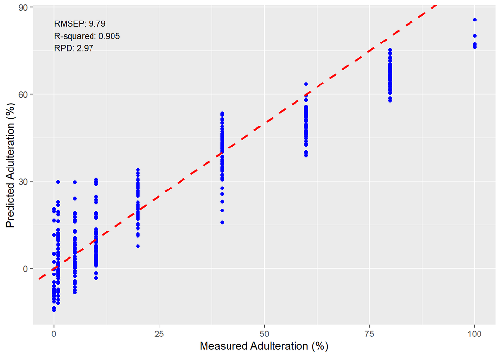

```r
# predicted vs observed line and scatter
# Create a data frame
results_df <- data.frame(observed=observed, predictions=predictions)

results_df %>%
  ggplot(aes(x = observed, y = predictions)) +
  geom_point(color = "blue") +
  geom_abline(slope = 1, intercept = 0, color = "red",
              linetype = "dashed", linewidth = 1) +
  labs( x = "Measured Adulteration (%)",
    y = "Predicted Adulteration (%)") +
  annotate("text",
    x = min(observed), y = max(predictions),
    label = paste("RMSEP:", round(RMSEP, 2),
      "\nR-squared:", round(R2, 3),
      "\nRPD:", round(RPD, 2)),
    hjust = 0, vjust = 1, size = 3, color = "black") +
  theme(
    axis.title = element_text(color = "black", size = 10),
    axis.text = element_text(color = "black"))+
  theme_gray()
```

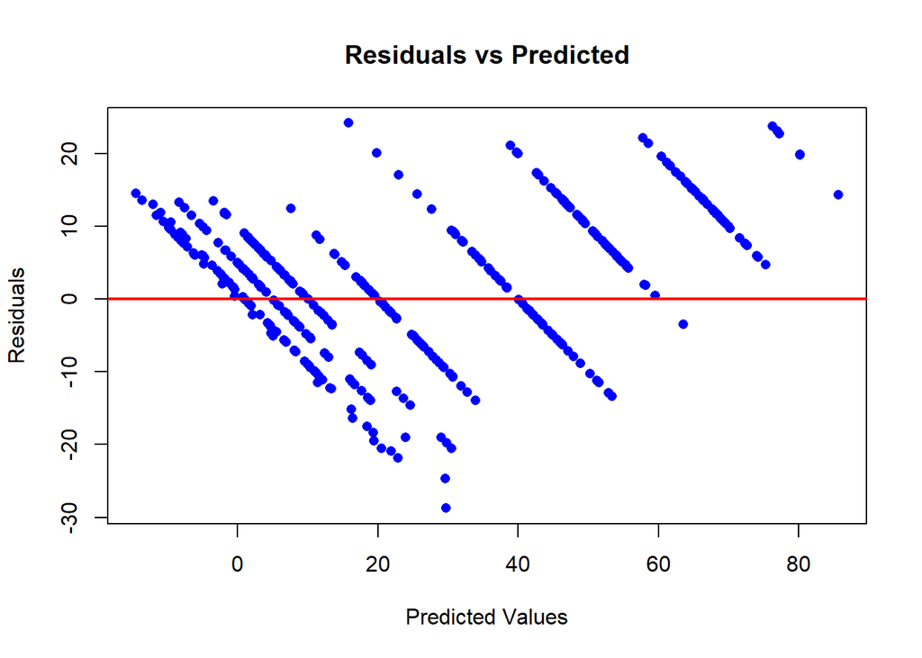

```r
# Check residuals

residuals <- observed - predictions

# Plot Residuals
plot(predictions, residuals,
     xlab = "Predicted Values",
     ylab = "Residuals",
     main = "Residuals vs Predicted",
     pch = 16, col = "blue")
abline(h = 0, col = "red", lwd = 2)
```

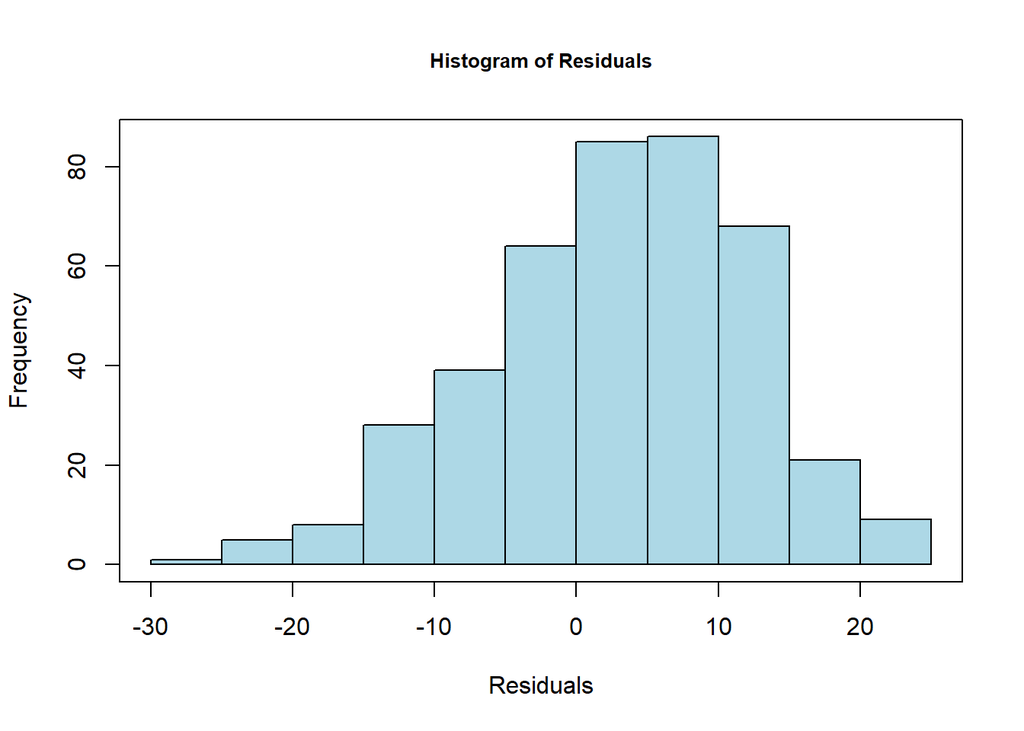

```r
hist(residuals,
     main = "Histogram of Residuals",
     xlab = "Residuals", cex.main = 0.8,
     col = "lightblue", border = "black"); box()
```

## Conclusion

- Elastic_net demonstrate very good performance in predicting adulteration in ground coffee. The model achieves an RPD value of 3.0. The model can make reliable predictions and is suitable for quality control.